DS 6030 | Fall 2024 | University of Virginia

# Homework #6: SVM and Calibration

Author

**Rohan Shroff**

Published

October 17, 2024

# Required R packages and Directories

```r
dir_data= 'https://mdporter.github.io/teaching/data/' # data directory
library(tidyverse)  # functions for data manipulation
library(ranger)
library(pROC)
```

# COMPAS Recidivism Prediction

A recidivism risk model called COMPAS was the topic of a [ProPublica article](https://www.propublica.org/article/machine-bias-risk-assessments-in-criminal-sentencing/) on ML bias. Because the data and notebooks used for article was released on [github](https://github.com/propublica/compas-analysis), we can also evaluate the prediction bias (i.e., calibration).

This code will read in the *violent crime* risk score and apply the filtering used in the [analysis](https://github.com/propublica/compas-analysis/blob/master/Compas%20Analysis.ipynb).

```r
library(tidyverse)
df = read_csv("https://raw.githubusercontent.com/propublica/compas-analysis/master/compas-scores-two-years-violent.csv")

risk = df %>%
  filter(days_b_screening_arrest <= 30) %>%
  filter(days_b_screening_arrest >= -30) %>%
  filter(is_recid != -1) %>%
  filter(c_charge_degree != "O") %>%
  filter(v_score_text != 'N/A') %>%
  transmute(
    age, age_cat,
    charge = ifelse(c_charge_degree == "F", "Felony", "Misdemeanor"),
    race,
    sex,
    priors_count = priors_count...15,
    score = v_decile_score,              # the risk score {1,2,...,10}
    outcome = two_year_recid...53        # outcome {1 = two year recidivate}
  )
```

The `risk` data frame has the relevant information for completing the problems.

# Problem 1: COMPAS risk score

## a. Risk Score and Probability (table)

Assess the predictive bias in the COMPAS risk scores by evaluating the probability of recidivism, e.g. estimate $\Pr(Y = 1 \mid \text{Score}=x)$. Use any reasonable techniques (including Bayesian) to estimate the probability of recidivism for each risk score.

Specifically, create a table (e.g., data frame) that provides the following information:

- The COMPASS risk score.
- The point estimate of the probability of recidivism for each risk score.
- 95% confidence or credible intervals for the probability (e.g., Using normal theory, bootstrap, or Bayesian techniques).

Indicate the choices you made in estimation (e.g., state the prior if you used Bayesian methods).

**Solution**

For this analysis, I used normal theory to make my confidence intervals. I also use a random forest model.

```r
risk_rf <- ranger(outcome~score, num.trees=1000, probability = TRUE, data=risk)
```

```r
predictions <-  risk_rf$predictions[,2]
predictions1 <- data.frame(predictions)

risk_pred = cbind(risk, predictions1)
head(risk_pred, 10)
```

```
   age         age_cat      charge             race    sex priors_count score
1   69 Greater than 45      Felony            Other   Male            0     1
2   34         25 - 45      Felony African-American   Male            0     1
3   44         25 - 45 Misdemeanor            Other   Male            0     1
4   43         25 - 45      Felony            Other   Male            3     3
5   39         25 - 45 Misdemeanor        Caucasian Female            0     1
6   27         25 - 45      Felony        Caucasian   Male            0     4
7   37         25 - 45 Misdemeanor        Caucasian Female            0     1
8   41         25 - 45      Felony African-American   Male            0     2
9   37         25 - 45 Misdemeanor         Hispanic   Male            0     1
10  25         25 - 45      Felony African-American   Male            3     9
   outcome predictions
1        0      0.0622
2        1      0.0613
3        0      0.0619
4        0      0.1720
5        0      0.0623
6        0      0.1750
7        0      0.0622
8        0      0.0935
9        0      0.0624
10       0      0.5643
```

```r
risk_grouped <-  risk_pred %>%
  group_by(score) %>%
  summarize(percent=mean(predictions, na.rm = TRUE),
            count=n())
risk_grouped
```

```
# A tibble: 10 × 3
  score percent count
  <dbl>   <dbl> <int>
1     1  0.0621  1340
2     2  0.0932   622
3     3  0.172    543
4     4  0.176    408
5     5  0.184    325
6     6  0.284    300
# ℹ 4 more rows
```

```r
risk_grouped['lwr_bound'] <- risk_grouped['percent'] - 1.96*((risk_grouped['percent']*(1-risk_grouped['percent']))/risk_grouped['count'])^0.5

risk_grouped['upr_bound'] <- risk_grouped['percent'] + 1.96*((risk_grouped['percent']*(1-risk_grouped['percent']))/risk_grouped['count'])^0.5
```

```r
risk_grouped
```

```
# A tibble: 10 × 5
  score percent count lwr_bound upr_bound
  <dbl>   <dbl> <int>     <dbl>     <dbl>
1     1  0.0621  1340    0.0492    0.0751
2     2  0.0932   622    0.0704    0.116
3     3  0.172    543    0.140     0.203
4     4  0.176    408    0.139     0.213
5     5  0.184    325    0.142     0.226
6     6  0.284    300    0.233     0.335
# ℹ 4 more rows
```

## b. Risk Score and Probability (plot)

Make a plot of the risk scores and corresponding estimated probability of recidivism.

- Put the risk score on the x-axis and estimate probability of recidivism on y-axis.
- Add the 95% confidence or credible intervals calculated in part a.
- Comment on the patterns you see.

**Solution**

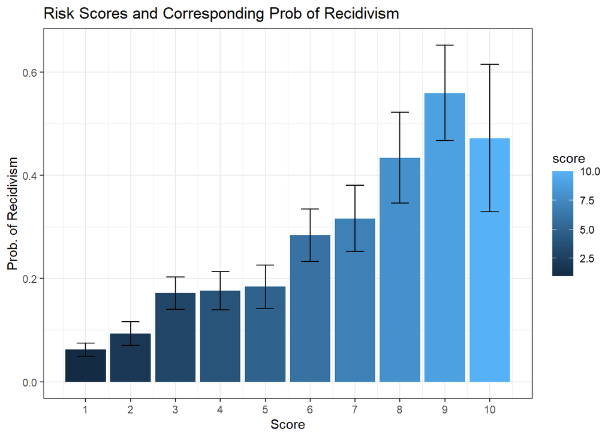

```r
ggplot(data = risk_grouped, aes(x=score, y = percent)) +
  geom_col(aes(fill=score)) +
  geom_errorbar(aes(ymin=lwr_bound, ymax=upr_bound), width = 0.4) +
  scale_x_continuous(breaks=1:10) +
  labs(title = 'Risk Scores and Corresponding Prob of Recidivism', x = 'Score', y = 'Prob. of Recidivism')
```

In general, we can see that as the score of an individual increases, the forecasted probability of them recidivizing goes up.

## c. Risk Score and Probability (by race)

Repeat the analysis, but this time do so for every race. Produce a set of plots (one per race) and comment on the patterns.

**Solution**

```r
risk_grouped_race <- risk_pred %>%
  group_by(score, race) %>%
  summarize(percent=mean(predictions, na.rm = TRUE),
            count=n())
risk_grouped_race['lwr_bound'] <- risk_grouped_race['percent'] - 1.96*((risk_grouped_race['percent']*(1-risk_grouped_race['percent']))/risk_grouped_race['count'])^0.5

risk_grouped_race['upr_bound'] <- risk_grouped_race['percent'] + 1.96*((risk_grouped_race['percent']*(1-risk_grouped_race['percent']))/risk_grouped_race['count'])^0.5
```

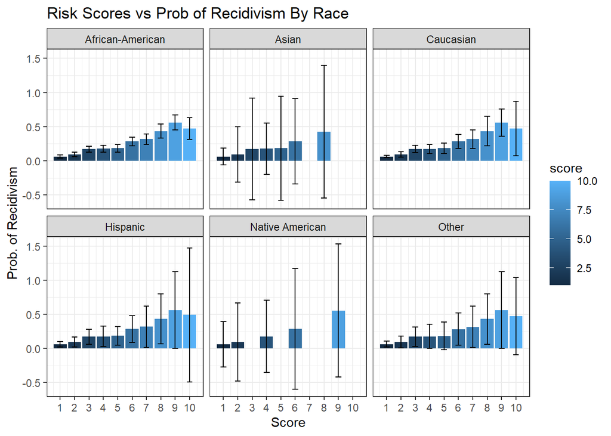

```r
ggplot(data = risk_grouped_race, aes(x=score, y = percent)) +
  geom_col(aes(fill=score)) +
  geom_errorbar(aes(ymin=lwr_bound, ymax=upr_bound), width = 0.4) +
  facet_wrap(~race)+
  scale_x_continuous(breaks=1:10) +
  labs(title = 'Risk Scores vs Prob of Recidivism By Race', x = 'Score', y = 'Prob. of Recidivism')
```

From the plots we can see that data is sparse for Asians and Native Americans. Another strange observation that may be due to insufficient sample size is that most racial groups are assigned a lower probability of recidivizing when they have a score of 10 compared to 9.

## d. ROC Curves

Use the raw COMPAS risk scores to make a ROC curve for each race.

- Are the best discriminating models the ones you expected?
- Are the ROC curves helpful in evaluating the COMPAS risk score?

**Solution**

```r
risk_pred['predictions_class'] <- ifelse(risk_pred$predictions > 0.20, 1, 0)

roc_AA <- risk_pred %>%
  filter(race == 'African-American')

roc_curve_AA <- roc(roc_AA[,'outcome'], roc_AA[,'predictions_class'])
roc_Asian <- risk_pred %>%
  filter(race == 'Asian')

roc_curve_A <- roc(roc_Asian[,'outcome'], roc_Asian[,'predictions_class'])
roc_C <- risk_pred %>%
  filter(race == 'Caucasian')

roc_curve_C <- roc(roc_C[,'outcome'], roc_C[,'predictions_class'])
roc_H <- risk_pred %>%
  filter(race == 'Hispanic')

roc_curve_H <- roc(roc_H[,'outcome'], roc_H[,'predictions_class'])
roc_NA <- risk_pred %>%
  filter(race == 'Native American')

roc_curve_NA <- roc(roc_NA[,'outcome'], roc_NA[,'predictions_class'])
roc_O <- risk_pred %>%
  filter(race == 'Other')

roc_curve_O <- roc(roc_O[,'outcome'], roc_O[,'predictions_class'])
```

```r
roc_AA_data <- data.frame(FPR = (1-roc_curve_AA$specificities), TPR = roc_curve_AA$sensitivities, model = 'African-American')

roc_A_data <- data.frame(FPR = (1-roc_curve_A$specificities), TPR = roc_curve_A$sensitivities, model = 'Asian')

roc_C_data <- data.frame(FPR = (1-roc_curve_C$specificities), TPR = roc_curve_C$sensitivities, model = 'Caucasian')

roc_H_data <- data.frame(FPR = (1-roc_curve_H$specificities), TPR = roc_curve_H$sensitivities, model = 'Hispanic')

roc_NA_data <- data.frame(FPR = (1-roc_curve_NA$specificities), TPR = roc_curve_NA$sensitivities, model = 'Native American')

roc_O_data <- data.frame(FPR = (1-roc_curve_O$specificities), TPR = roc_curve_O$sensitivities, model = 'Other')
```

```r
roc_df_comb <- rbind(roc_AA_data, roc_A_data, roc_C_data, roc_H_data, roc_NA_data, roc_O_data)
```

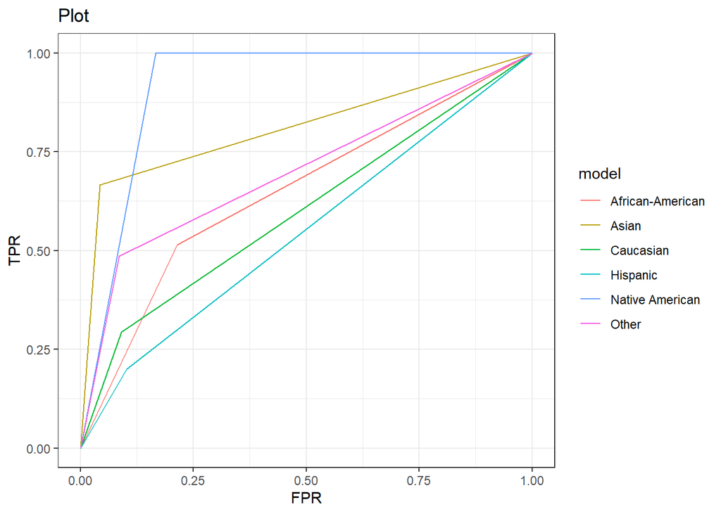

```r
ggplot(roc_df_comb, aes(x=FPR)) +
  geom_line(aes(y=TPR, color = model)) +
  labs(title = 'Plot', x = 'FPR', y = 'TPR')
```

From the ROC curve, it becomes apparent that my random forest model performs best for Native Americans and is the worst for Caucasian and Hispanics. This result is very surprising because Native Americans were the smallest sample size. I also think that the ROC curves are not too helpful in evaluating the COMPAS risk scores because the ROC curves simply show the TPR when a certain FPR is chosen by a threshold value. A better way to evaluate compass score would be to do a linear regression of score and the percent of people that recidivized.

# Problem 2: Support Vector Machines (SVM)

Focus on Problem 1, we won’t have an SVM problem this week.